# Spoton Data Exploration

This notebook serves as a playground for the following tasks:

- Get an understanding of the data at hand
- Create visualizations
- Do analysis and feature engineering
- Develop ready to use pipeline

```python
import os
import pandas as pd
import numpy as np
import seaborn as sns
import matplotlib.pyplot as plt
from datetime import datetime
import matplotlib.patheffects as PathEffects
from math import pi
```

## Loading of the extracted data and initial assessment

```python
data_folder = 'data'

# get the file handles
trackinfo = [os.path.join(data_folder, f) for f in os.listdir(data_folder) if os.path.isfile(os.path.join(data_folder, f)) and 'trackinfo' in f][0]
trackfeatures = [os.path.join(data_folder, f) for f in os.listdir(data_folder) if os.path.isfile(os.path.join(data_folder, f)) and 'trackfeatures' in f][0]

pd_trackinfo = pd.read_pickle(trackinfo)
pd_trackfeatures = pd.read_pickle(trackfeatures)
```

#### Trackinfo

```python
pd_trackinfo.head()
```

|  | album | artists | available_markets | disc_number | duration_ms | explicit | external_ids | external_urls | href | id | is_local | name | popularity | preview_url | track_number | type | uri |
| --- | --- | --- | --- | --- | --- | --- | --- | --- | --- | --- | --- | --- | --- | --- | --- | --- | --- |
| 0 | {'album_type': 'single', 'artists': [{'externa... | [{'external_urls': {'spotify': 'https://open.s... | [] | 1 | 243839 | False | {'isrc': 'USWB11701603'} | {'spotify': 'https://open.spotify.com/track/01... | https://api.spotify.com/v1/tracks/01FwoJVHy55B... | 01FwoJVHy55BqEzf9hTtyf | False | Darker Than The Light That Never Bleeds - Ches... | 0 | None | 1 | track | spotify:track:01FwoJVHy55BqEzf9hTtyf |
| 1 | {'album_type': 'single', 'artists': [{'externa... | [{'external_urls': {'spotify': 'https://open.s... | [] | 1 | 259764 | False | {'isrc': 'CA6D21700236'} | {'spotify': 'https://open.spotify.com/track/0L... | https://api.spotify.com/v1/tracks/0LTq2r4sWXgr... | 0LTq2r4sWXgrlJk5gfjanc | False | By Your Side (feat. Emel) | 24 | None | 1 | track | spotify:track:0LTq2r4sWXgrlJk5gfjanc |
| 2 | {'album_type': 'single', 'artists': [{'externa... | [{'external_urls': {'spotify': 'https://open.s... | [AD, AE, AR, AT, AU, BE, BG, BH, BO, BR, CA, C... | 1 | 160312 | False | {'isrc': 'NLQ8D1700559'} | {'spotify': 'https://open.spotify.com/track/0d... | https://api.spotify.com/v1/tracks/0d04hp9JU5pk... | 0d04hp9JU5pkMoSFotxkmY | False | Alone Tonight | 27 | https://p.scdn.co/mp3-preview/b98fee9a97f3d755... | 1 | track | spotify:track:0d04hp9JU5pkMoSFotxkmY |
| 3 | {'album_type': 'single', 'artists': [{'externa... | [{'external_urls': {'spotify': 'https://open.s... | [AD, AE, AR, AT, AU, BE, BG, BH, BO, BR, CA, C... | 1 | 215629 | False | {'isrc': 'CA5KR1558775'} | {'spotify': 'https://open.spotify.com/track/14... | https://api.spotify.com/v1/tracks/144Jdqnukv2z... | 144Jdqnukv2zebyt6vq9H8 | False | Crash The Party | 32 | https://p.scdn.co/mp3-preview/c07475ee9c86f9cd... | 1 | track | spotify:track:144Jdqnukv2zebyt6vq9H8 |
| 4 | {'album_type': 'compilation', 'artists': [{'ex... | [{'external_urls': {'spotify': 'https://open.s... | [AD, AE, AR, AT, AU, BE, BG, BH, BO, BR, CA, C... | 1 | 224000 | False | {'isrc': 'NLF711508382'} | {'spotify': 'https://open.spotify.com/track/1L... | https://api.spotify.com/v1/tracks/1LWM8ybNxkIW... | 1LWM8ybNxkIWf8QqEafcP1 | False | Black Coffee | 22 | https://p.scdn.co/mp3-preview/fa1abf7821f5cc16... | 14 | track | spotify:track:1LWM8ybNxkIWf8QqEafcP1 |

```python
pd_trackinfo.shape
```

```
(951, 17)
```

There are not many features helpful for our purpose. Most of them I will drop without further comments. Some of the features are notheworthy:

- available_markets - One could further improve our model by introducing the markets on which a track is being offered. This could further define a users taste.
- explicit - An easy to understand flag. Tells a lot about the music. Example: Mozart might not fit well in a playlist with Eminem.
- popularity - An interesting attribute. Might be useful.
- duration_ms - Can be dropped as it is also available in trackfeatures

```python
columns_to_drop = ['album', 'artists', 'available_markets', 'disc_number',
                   'duration_ms', 'external_ids', 'external_urls', 'href',
                   'is_local', 'name', 'preview_url', 'track_number', 'type',
                   'uri']
pd_trackinfo.drop(columns_to_drop, axis=1, inplace=True)
```

Let's check for duplicate records.

```python
print(pd_trackinfo.shape, pd_trackinfo[pd_trackinfo.duplicated()].shape)
```

```
(951, 3) (6, 3)
```

```python
pd_trackinfo.drop_duplicates(inplace=False)
```

|  | explicit | id | popularity |
| --- | --- | --- | --- |
| 0 | False | 01FwoJVHy55BqEzf9hTtyf | 0 |
| 1 | False | 0LTq2r4sWXgrlJk5gfjanc | 24 |
| 2 | False | 0d04hp9JU5pkMoSFotxkmY | 27 |
| 3 | False | 144Jdqnukv2zebyt6vq9H8 | 32 |
| 4 | False | 1LWM8ybNxkIWf8QqEafcP1 | 22 |
| 5 | False | 4weZBTWBtfQQRUJKVMZOsE | 32 |
| 6 | False | 1swtjhwXhJlYtuzqXKfQoD | 40 |
| 7 | False | 1uSAGG6FRvrjI22HyGDayU | 38 |
| 8 | False | 2UkRIWOvxCYVpyqNTwy9dE | 37 |
| 9 | False | 303QJcPey7DrwoIQzHAEjm | 29 |
| 10 | False | 3F1hkIYH8AImRNIqbKSMXQ | 34 |
| 11 | False | 1H4M2sr1CA1pOkg35btO0C | 15 |
| 12 | False | 46L9j7CjtctvVNSZTmEJrx | 42 |
| 13 | False | 10IR5pzbX5dv4as7Uf7hts | 23 |
| 14 | False | 4SV8h3RlcuQc9jE9MUQfFF | 25 |
| 15 | False | 4bKEp7eKqNGySpKZX5mCed | 45 |
| 16 | False | 4yzc9GjCMUyG41cNeu7eiE | 40 |
| 17 | False | 55jk70uGhiwfFCGXJRhcNW | 39 |
| 18 | False | 56ktw0cBP5vGO5pmUsy9q4 | 30 |
| 19 | False | 5AfzDfY1NzipDdfbVBCzlM | 21 |
| 20 | False | 5GO9eq5Xu2G8waqwjZjUYI | 51 |
| 21 | True | 5MEgfTEmK5KeRAoQo6W5rM | 40 |
| 22 | False | 5dZlxXy2MxUWQ7buue0f62 | 27 |
| 23 | False | 6MrKIOtWxBnDXycdZmQvrt | 28 |
| 24 | False | 6aeqAwf4vfQeWFSjmgZCEB | 32 |
| 25 | False | 74TdUlQYu09uAgZEbBZ58j | 21 |
| 26 | False | 782YlCwsXdlu2myUme4zyu | 41 |
| 27 | False | 7Mcbk8CghT5wE6j4WfG2uQ | 47 |
| 28 | False | 7nGUyNRgzjQ4lnyvJqXvNO | 11 |
| 29 | False | 7sggd2ZlSvC10u6389Yn4k | 17 |
| ... | ... | ... | ... |
| 921 | False | 6z7LM4N54IRNJfH9n2dmla | 27 |
| 922 | False | 0QbmgtJumFrnhunEljYLdm | 27 |
| 923 | False | 0HnV5R4fBuNCoh6XDetQmj | 51 |
| 924 | False | 0wkEdDhLfUbJWsiBcdSn1S | 30 |
| 925 | False | 142jMpGhzJl0E7twPAkbY2 | 57 |
| 926 | False | 18VPI5WxIe5gFUf9FLLWfS | 39 |
| 927 | False | 1EhCqGJfNj4LImGbnpEzXo | 32 |
| 928 | False | 1G0Fs0eAznJy9sPf1LwOGr | 27 |
| 929 | False | 1TOs3Ih3404J9ExtugB7pl | 34 |
| 930 | False | 1oRy2CCBaWCVqJRkmyGWLx | 60 |
| 931 | False | 2R0Jp0FUcLnXRJsUhdCrhq | 27 |
| 932 | False | 2ZfQyCU4ZGHRXlOIJOqw4e | 34 |
| 933 | False | 39y4GUCaWhC4BKArUUhE8p | 30 |
| 934 | False | 3G8JTITtEFBHAHNSlrgVR4 | 42 |
| 935 | False | 3XussQ7yygu3uoAPEDlwhi | 48 |
| 936 | False | 454pTBJhThN8MhQUyKCDn8 | 28 |
| 937 | False | 0DNburPSI37graB2ueQo20 | 31 |
| 938 | False | 4ucGYVIyKSyWSr5pXU85yR | 40 |
| 939 | False | 5ODbolFek8icPQDO7ZEeHP | 44 |
| 940 | False | 5lrKqbQQgG4QkWpCcFjZT8 | 32 |
| 941 | False | 6SgM24gAhunbOMPDkIllNw | 39 |
| 942 | False | 6ataxZgJtC7OROpznt1V5A | 42 |
| 943 | True | 6cxOCfqWLoIhiTXLRZQW7L | 37 |
| 944 | False | 6dqvyjRaNVP8ALsm4WZNLH | 33 |
| 945 | False | 6e5vXe4E9GT7juN4gT2DYd | 30 |
| 946 | False | 6gbilykEMv3ahTQNT6W570 | 39 |
| 947 | False | 3u3YMLtbaogSOhyLMLVU0c | 42 |
| 948 | False | 777lzBBmmHCv1d0ADMjRcL | 40 |
| 949 | False | 4m9AUXzAE0YkO33xzpLCKc | 41 |
| 950 | False | 7rnQUKsOAzWhPsb92ktyNF | 40 |

945 rows × 3 columns

#### Trackfeatures

```python
pd_trackfeatures.head()
```

|  | acousticness | analysis_url | danceability | duration_ms | energy | id | instrumentalness | key | liveness | loudness | mode | speechiness | tempo | time_signature | track_href | type | uri | valence |
| --- | --- | --- | --- | --- | --- | --- | --- | --- | --- | --- | --- | --- | --- | --- | --- | --- | --- | --- |
| 0 | 0.011500 | https://api.spotify.com/v1/audio-analysis/01Fw... | 0.684 | 243840 | 0.918 | 01FwoJVHy55BqEzf9hTtyf | 0.133000 | 5 | 0.1310 | -3.389 | 1 | 0.0463 | 124.959 | 4 | https://api.spotify.com/v1/tracks/01FwoJVHy55B... | audio_features | spotify:track:01FwoJVHy55BqEzf9hTtyf | 0.160 |
| 1 | 0.007800 | https://api.spotify.com/v1/audio-analysis/0LTq... | 0.448 | 259765 | 0.880 | 0LTq2r4sWXgrlJk5gfjanc | 0.000011 | 8 | 0.0955 | -3.076 | 1 | 0.1360 | 170.047 | 4 | https://api.spotify.com/v1/tracks/0LTq2r4sWXgr... | audio_features | spotify:track:0LTq2r4sWXgrlJk5gfjanc | 0.394 |
| 2 | 0.013800 | https://api.spotify.com/v1/audio-analysis/0d04... | 0.585 | 160312 | 0.933 | 0d04hp9JU5pkMoSFotxkmY | 0.013200 | 6 | 0.2000 | -3.927 | 0 | 0.0738 | 127.996 | 4 | https://api.spotify.com/v1/tracks/0d04hp9JU5pk... | audio_features | spotify:track:0d04hp9JU5pkMoSFotxkmY | 0.262 |
| 3 | 0.001370 | https://api.spotify.com/v1/audio-analysis/144J... | 0.626 | 215630 | 0.856 | 144Jdqnukv2zebyt6vq9H8 | 0.533000 | 8 | 0.1610 | -4.937 | 1 | 0.0565 | 127.989 | 4 | https://api.spotify.com/v1/tracks/144Jdqnukv2z... | audio_features | spotify:track:144Jdqnukv2zebyt6vq9H8 | 0.333 |
| 4 | 0.000319 | https://api.spotify.com/v1/audio-analysis/1LWM... | 0.503 | 224000 | 0.969 | 1LWM8ybNxkIWf8QqEafcP1 | 0.584000 | 9 | 0.3620 | -5.737 | 1 | 0.0405 | 139.981 | 4 | https://api.spotify.com/v1/tracks/1LWM8ybNxkIW... | audio_features | spotify:track:1LWM8ybNxkIWf8QqEafcP1 | 0.288 |

```python
pd_trackfeatures.shape
```

```
(951, 18)
```

Compared to trackinfo, we do have a lot of useful columns in the trackfeatures. There are some obvious ones, which are completely useless for our cause. Hence, we will just drop them.

```python
columns_to_drop = ['analysis_url', 'track_href', 'type', 'uri']
pd_trackfeatures.drop(columns_to_drop, axis=1, inplace=True)
```

Let's check for duplicate records too.

```python
print(pd_trackfeatures.shape, pd_trackfeatures[pd_trackfeatures.duplicated()].shape)
```

```
(951, 14) (6, 14)
```

```python
pd_trackfeatures.drop_duplicates(inplace=False)
```

|  | acousticness | danceability | duration_ms | energy | id | instrumentalness | key | liveness | loudness | mode | speechiness | tempo | time_signature | valence |
| --- | --- | --- | --- | --- | --- | --- | --- | --- | --- | --- | --- | --- | --- | --- |
| 0 | 0.011500 | 0.684 | 243840 | 0.918 | 01FwoJVHy55BqEzf9hTtyf | 0.133000 | 5 | 0.1310 | -3.389 | 1 | 0.0463 | 124.959 | 4 | 0.1600 |
| 1 | 0.007800 | 0.448 | 259765 | 0.880 | 0LTq2r4sWXgrlJk5gfjanc | 0.000011 | 8 | 0.0955 | -3.076 | 1 | 0.1360 | 170.047 | 4 | 0.3940 |
| 2 | 0.013800 | 0.585 | 160312 | 0.933 | 0d04hp9JU5pkMoSFotxkmY | 0.013200 | 6 | 0.2000 | -3.927 | 0 | 0.0738 | 127.996 | 4 | 0.2620 |
| 3 | 0.001370 | 0.626 | 215630 | 0.856 | 144Jdqnukv2zebyt6vq9H8 | 0.533000 | 8 | 0.1610 | -4.937 | 1 | 0.0565 | 127.989 | 4 | 0.3330 |
| 4 | 0.000319 | 0.503 | 224000 | 0.969 | 1LWM8ybNxkIWf8QqEafcP1 | 0.584000 | 9 | 0.3620 | -5.737 | 1 | 0.0405 | 139.981 | 4 | 0.2880 |
| 5 | 0.220000 | 0.534 | 206757 | 0.920 | 4weZBTWBtfQQRUJKVMZOsE | 0.000000 | 0 | 0.1860 | -2.555 | 1 | 0.0673 | 154.673 | 4 | 0.4410 |
| 6 | 0.019800 | 0.362 | 253492 | 0.926 | 1swtjhwXhJlYtuzqXKfQoD | 0.069700 | 2 | 0.1060 | -4.175 | 1 | 0.1090 | 127.933 | 4 | 0.1400 |
| 7 | 0.032800 | 0.519 | 278710 | 0.629 | 1uSAGG6FRvrjI22HyGDayU | 0.000841 | 0 | 0.1070 | -5.745 | 0 | 0.0578 | 123.986 | 4 | 0.1020 |
| 8 | 0.001310 | 0.311 | 188618 | 0.820 | 2UkRIWOvxCYVpyqNTwy9dE | 0.032300 | 0 | 0.4330 | -8.751 | 0 | 0.0683 | 150.442 | 4 | 0.1300 |
| 9 | 0.035300 | 0.563 | 163304 | 0.871 | 303QJcPey7DrwoIQzHAEjm | 0.775000 | 6 | 0.1350 | -5.266 | 0 | 0.0584 | 149.939 | 4 | 0.5060 |
| 10 | 0.007530 | 0.473 | 214888 | 0.893 | 3F1hkIYH8AImRNIqbKSMXQ | 0.000018 | 6 | 0.4810 | -6.079 | 0 | 0.0717 | 130.108 | 4 | 0.2470 |
| 11 | 0.000230 | 0.528 | 202977 | 0.909 | 1H4M2sr1CA1pOkg35btO0C | 0.191000 | 1 | 0.3790 | -5.182 | 0 | 0.0378 | 137.942 | 3 | 0.3750 |
| 12 | 0.003680 | 0.578 | 219813 | 0.695 | 46L9j7CjtctvVNSZTmEJrx | 0.000000 | 7 | 0.3070 | -5.531 | 1 | 0.0360 | 107.003 | 4 | 0.1680 |
| 13 | 0.003370 | 0.545 | 188439 | 0.903 | 10IR5pzbX5dv4as7Uf7hts | 0.938000 | 1 | 0.0479 | -7.814 | 1 | 0.0438 | 130.027 | 4 | 0.4850 |
| 14 | 0.000011 | 0.461 | 189104 | 0.863 | 4SV8h3RlcuQc9jE9MUQfFF | 0.747000 | 1 | 0.5050 | -11.098 | 1 | 0.0440 | 132.006 | 4 | 0.0787 |
| 15 | 0.003790 | 0.419 | 243125 | 0.846 | 4bKEp7eKqNGySpKZX5mCed | 0.008460 | 8 | 0.5080 | -5.252 | 0 | 0.1270 | 149.968 | 4 | 0.0655 |
| 16 | 0.016100 | 0.615 | 210000 | 0.728 | 4yzc9GjCMUyG41cNeu7eiE | 0.152000 | 4 | 0.1950 | -3.270 | 0 | 0.0434 | 127.945 | 4 | 0.0394 |
| 17 | 0.006530 | 0.486 | 199826 | 0.957 | 55jk70uGhiwfFCGXJRhcNW | 0.003180 | 4 | 0.3900 | -3.349 | 0 | 0.0628 | 131.917 | 4 | 0.2550 |
| 18 | 0.000405 | 0.546 | 236000 | 0.829 | 56ktw0cBP5vGO5pmUsy9q4 | 0.704000 | 7 | 0.1440 | -9.006 | 1 | 0.0694 | 125.943 | 4 | 0.5780 |
| 19 | 0.001160 | 0.693 | 390000 | 0.925 | 5AfzDfY1NzipDdfbVBCzlM | 0.017400 | 5 | 0.3290 | -4.990 | 0 | 0.3530 | 127.994 | 4 | 0.2060 |
| 20 | 0.004480 | 0.502 | 195954 | 0.917 | 5GO9eq5Xu2G8waqwjZjUYI | 0.001000 | 7 | 0.1390 | -4.216 | 0 | 0.0732 | 75.997 | 4 | 0.1300 |
| 21 | 0.000845 | 0.583 | 206871 | 0.972 | 5MEgfTEmK5KeRAoQo6W5rM | 0.708000 | 1 | 0.0945 | -2.392 | 1 | 0.0933 | 159.989 | 4 | 0.3290 |
| 22 | 0.002450 | 0.413 | 231360 | 0.755 | 5dZlxXy2MxUWQ7buue0f62 | 0.000165 | 6 | 0.2810 | -5.565 | 0 | 0.0507 | 125.484 | 4 | 0.0650 |
| 23 | 0.008630 | 0.533 | 229500 | 0.880 | 6MrKIOtWxBnDXycdZmQvrt | 0.016100 | 8 | 0.1420 | -6.398 | 0 | 0.0831 | 150.044 | 4 | 0.5030 |
| 24 | 0.219000 | 0.642 | 254770 | 0.659 | 6aeqAwf4vfQeWFSjmgZCEB | 0.000000 | 5 | 0.5850 | -6.941 | 0 | 0.2520 | 130.016 | 4 | 0.4320 |
| 25 | 0.000173 | 0.647 | 392571 | 0.855 | 74TdUlQYu09uAgZEbBZ58j | 0.892000 | 0 | 0.0998 | -6.379 | 1 | 0.0390 | 139.992 | 4 | 0.1690 |
| 26 | 0.142000 | 0.527 | 202667 | 0.596 | 782YlCwsXdlu2myUme4zyu | 0.000077 | 1 | 0.1860 | -6.825 | 1 | 0.0479 | 180.003 | 4 | 0.0865 |
| 27 | 0.000422 | 0.568 | 352162 | 0.931 | 7Mcbk8CghT5wE6j4WfG2uQ | 0.665000 | 4 | 0.1400 | -7.077 | 0 | 0.0481 | 128.008 | 4 | 0.0420 |
| 28 | 0.000526 | 0.533 | 216579 | 0.963 | 7nGUyNRgzjQ4lnyvJqXvNO | 0.708000 | 1 | 0.3880 | -5.008 | 1 | 0.0481 | 133.041 | 4 | 0.0612 |
| 29 | 0.055300 | 0.456 | 218182 | 0.868 | 7sggd2ZlSvC10u6389Yn4k | 0.002830 | 9 | 0.1850 | -6.427 | 0 | 0.0496 | 131.912 | 4 | 0.3010 |
| ... | ... | ... | ... | ... | ... | ... | ... | ... | ... | ... | ... | ... | ... | ... |
| 921 | 0.054500 | 0.561 | 189754 | 0.905 | 6z7LM4N54IRNJfH9n2dmla | 0.005900 | 11 | 0.0872 | -5.305 | 0 | 0.1610 | 127.962 | 4 | 0.3730 |
| 922 | 0.046500 | 0.728 | 266344 | 0.777 | 0QbmgtJumFrnhunEljYLdm | 0.853000 | 8 | 0.1350 | -7.837 | 0 | 0.0545 | 128.024 | 4 | 0.1800 |
| 923 | 0.002640 | 0.507 | 181943 | 0.861 | 0HnV5R4fBuNCoh6XDetQmj | 0.001010 | 3 | 0.6430 | -3.302 | 0 | 0.0938 | 127.964 | 4 | 0.2380 |
| 924 | 0.000823 | 0.527 | 403453 | 0.870 | 0wkEdDhLfUbJWsiBcdSn1S | 0.819000 | 0 | 0.1580 | -8.897 | 0 | 0.0361 | 138.014 | 4 | 0.2240 |
| 925 | 0.029400 | 0.452 | 189787 | 0.848 | 142jMpGhzJl0E7twPAkbY2 | 0.000000 | 1 | 0.7200 | -4.036 | 0 | 0.0486 | 127.933 | 4 | 0.1480 |
| 926 | 0.372000 | 0.701 | 167419 | 0.883 | 18VPI5WxIe5gFUf9FLLWfS | 0.000025 | 9 | 0.1990 | -2.722 | 0 | 0.1950 | 124.012 | 4 | 0.4720 |
| 927 | 0.101000 | 0.611 | 195767 | 0.986 | 1EhCqGJfNj4LImGbnpEzXo | 0.000028 | 11 | 0.1060 | -1.330 | 0 | 0.2120 | 144.016 | 4 | 0.3820 |
| 928 | 0.006070 | 0.273 | 173913 | 0.981 | 1G0Fs0eAznJy9sPf1LwOGr | 0.404000 | 5 | 0.5910 | -4.056 | 1 | 0.0725 | 103.480 | 4 | 0.1740 |
| 929 | 0.025300 | 0.887 | 160106 | 0.618 | 1TOs3Ih3404J9ExtugB7pl | 0.148000 | 2 | 0.3260 | -4.950 | 1 | 0.0788 | 128.011 | 4 | 0.4490 |
| 930 | 0.049500 | 0.704 | 176129 | 0.905 | 1oRy2CCBaWCVqJRkmyGWLx | 0.000165 | 1 | 0.3390 | -4.959 | 0 | 0.1240 | 123.968 | 4 | 0.4190 |
| 931 | 0.039800 | 0.623 | 251250 | 0.737 | 2R0Jp0FUcLnXRJsUhdCrhq | 0.000025 | 6 | 0.1410 | -4.725 | 0 | 0.0560 | 128.007 | 4 | 0.3810 |
| 932 | 0.000158 | 0.565 | 159375 | 0.977 | 2ZfQyCU4ZGHRXlOIJOqw4e | 0.876000 | 1 | 0.2070 | -2.202 | 1 | 0.0820 | 127.983 | 4 | 0.2650 |
| 933 | 0.024800 | 0.777 | 299130 | 0.829 | 39y4GUCaWhC4BKArUUhE8p | 0.877000 | 5 | 0.0812 | -8.859 | 0 | 0.0854 | 138.013 | 4 | 0.0774 |
| 934 | 0.000599 | 0.593 | 213658 | 0.937 | 3G8JTITtEFBHAHNSlrgVR4 | 0.865000 | 9 | 0.0790 | -4.357 | 0 | 0.0722 | 128.033 | 4 | 0.1220 |
| 935 | 0.037700 | 0.365 | 179501 | 0.705 | 3XussQ7yygu3uoAPEDlwhi | 0.258000 | 6 | 0.3960 | -5.984 | 0 | 0.0887 | 148.230 | 4 | 0.2290 |
| 936 | 0.000048 | 0.486 | 182538 | 0.898 | 454pTBJhThN8MhQUyKCDn8 | 0.003300 | 7 | 0.2760 | -5.491 | 1 | 0.0326 | 129.985 | 4 | 0.0566 |
| 937 | 0.000104 | 0.577 | 206830 | 0.945 | 0DNburPSI37graB2ueQo20 | 0.752000 | 8 | 0.1740 | -5.055 | 1 | 0.1130 | 146.049 | 4 | 0.3230 |
| 938 | 0.005320 | 0.622 | 246771 | 0.920 | 4ucGYVIyKSyWSr5pXU85yR | 0.122000 | 5 | 0.0783 | -6.347 | 0 | 0.1500 | 144.016 | 4 | 0.0620 |
| 939 | 0.013900 | 0.618 | 243474 | 0.905 | 5ODbolFek8icPQDO7ZEeHP | 0.195000 | 4 | 0.0620 | -4.529 | 0 | 0.0921 | 138.018 | 4 | 0.1840 |
| 940 | 0.020200 | 0.623 | 229192 | 0.855 | 5lrKqbQQgG4QkWpCcFjZT8 | 0.893000 | 9 | 0.2970 | -8.758 | 0 | 0.0301 | 140.111 | 4 | 0.3950 |
| 941 | 0.004650 | 0.783 | 237923 | 0.711 | 6SgM24gAhunbOMPDkIllNw | 0.818000 | 0 | 0.1110 | -4.923 | 1 | 0.1220 | 142.974 | 4 | 0.1390 |
| 942 | 0.045700 | 0.529 | 215997 | 0.826 | 6ataxZgJtC7OROpznt1V5A | 0.000084 | 3 | 0.1720 | -5.293 | 0 | 0.0396 | 130.079 | 4 | 0.3690 |
| 943 | 0.000670 | 0.406 | 195053 | 0.744 | 6cxOCfqWLoIhiTXLRZQW7L | 0.000000 | 2 | 0.6440 | -6.995 | 1 | 0.0313 | 171.011 | 4 | 0.7040 |
| 944 | 0.004000 | 0.824 | 210732 | 0.867 | 6dqvyjRaNVP8ALsm4WZNLH | 0.870000 | 3 | 0.1950 | -4.674 | 0 | 0.0418 | 122.989 | 4 | 0.3380 |
| 945 | 0.002840 | 0.554 | 277412 | 0.974 | 6e5vXe4E9GT7juN4gT2DYd | 0.417000 | 6 | 0.1070 | -4.713 | 0 | 0.0743 | 169.943 | 4 | 0.4700 |
| 946 | 0.017100 | 0.539 | 216021 | 0.887 | 6gbilykEMv3ahTQNT6W570 | 0.000030 | 1 | 0.0680 | -6.905 | 1 | 0.0582 | 150.017 | 4 | 0.3470 |
| 947 | 0.001060 | 0.499 | 169008 | 0.853 | 3u3YMLtbaogSOhyLMLVU0c | 0.001040 | 10 | 0.2600 | -5.626 | 0 | 0.0654 | 148.003 | 4 | 0.1120 |
| 948 | 0.001860 | 0.509 | 162026 | 0.574 | 777lzBBmmHCv1d0ADMjRcL | 0.000000 | 0 | 0.2580 | -7.541 | 1 | 0.0361 | 169.918 | 4 | 0.3320 |
| 949 | 0.000834 | 0.322 | 210270 | 0.862 | 4m9AUXzAE0YkO33xzpLCKc | 0.019800 | 0 | 0.4110 | -9.165 | 0 | 0.0861 | 138.444 | 4 | 0.2170 |
| 950 | 0.063000 | 0.662 | 200117 | 0.954 | 7rnQUKsOAzWhPsb92ktyNF | 0.010400 | 10 | 0.0653 | -3.347 | 1 | 0.0481 | 127.928 | 4 | 0.2550 |

945 rows × 14 columns

```python
pd_trackinfo.dtypes
```

```
explicit        bool
id            object
popularity     int64
dtype: object
```

```python
pd_trackfeatures.dtypes
```

```
acousticness        float64
danceability        float64
duration_ms           int64
energy              float64
id                   object
instrumentalness    float64
key                   int64
liveness            float64
loudness            float64
mode                  int64
speechiness         float64
tempo               float64
time_signature        int64
valence             float64
dtype: object
```

The features and their datatypes look now cleaned up.

```python
df = pd.merge(pd_trackinfo, pd_trackfeatures, on='id', suffixes=('_trackinfo','_trackfeatures'), how='inner')
```

```python
df.head()
```

|  | explicit | id | popularity | acousticness | danceability | duration_ms | energy | instrumentalness | key | liveness | loudness | mode | speechiness | tempo | time_signature | valence |
| --- | --- | --- | --- | --- | --- | --- | --- | --- | --- | --- | --- | --- | --- | --- | --- | --- |
| 0 | False | 01FwoJVHy55BqEzf9hTtyf | 0 | 0.011500 | 0.684 | 243840 | 0.918 | 0.133000 | 5 | 0.1310 | -3.389 | 1 | 0.0463 | 124.959 | 4 | 0.160 |
| 1 | False | 0LTq2r4sWXgrlJk5gfjanc | 24 | 0.007800 | 0.448 | 259765 | 0.880 | 0.000011 | 8 | 0.0955 | -3.076 | 1 | 0.1360 | 170.047 | 4 | 0.394 |
| 2 | False | 0d04hp9JU5pkMoSFotxkmY | 27 | 0.013800 | 0.585 | 160312 | 0.933 | 0.013200 | 6 | 0.2000 | -3.927 | 0 | 0.0738 | 127.996 | 4 | 0.262 |
| 3 | False | 144Jdqnukv2zebyt6vq9H8 | 32 | 0.001370 | 0.626 | 215630 | 0.856 | 0.533000 | 8 | 0.1610 | -4.937 | 1 | 0.0565 | 127.989 | 4 | 0.333 |
| 4 | False | 1LWM8ybNxkIWf8QqEafcP1 | 22 | 0.000319 | 0.503 | 224000 | 0.969 | 0.584000 | 9 | 0.3620 | -5.737 | 1 | 0.0405 | 139.981 | 4 | 0.288 |

```python
df.shape
```

```
(963, 16)
```

Oddly enough our shape is now wrong. Let's find the duplicates.

```python
df[df.duplicated()].shape
```

```
(18, 16)
```

```python
df.drop_duplicates(inplace=True)
```

Now that we have our dataframe, we can start with normalization.

## Cleanup & Normalization

Details can be found here: https://developer.spotify.com/documentation/web-api/reference/tracks/get-audio-features/

Let's see how the features currently correlate.

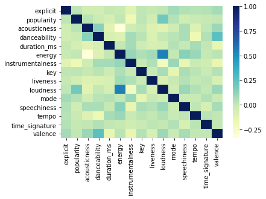

```python
sns.heatmap(df.corr(),cmap="YlGnBu")
```

Luckily the features do not strongly correlate. Loudness and Energy do seem to correlate a little but we can deal with this.

### Feature 'explicit'

```python
# explicit is boolean so it is by definition already an integer subclass. To avoid confusion, we will make explicit.
df['explicit_clean'] = df['explicit'].astype(float)
```

### Feature 'popularity'

```python
df['popularity'].unique()
```

```
array([ 0, 24, 27, 32, 22, 40, 38, 37, 29, 34, 15, 42, 23, 25, 45, 39, 30,
       21, 51, 28, 41, 47, 11, 17, 35, 43, 48, 57, 31, 26, 44, 49, 14, 36,
       50, 13, 55, 61,  1, 60, 19,  4, 20, 18, 33, 10, 46, 54, 16,  5, 52,
        9,  3, 53, 56, 63, 58, 65,  7,  6, 59, 64,  8, 67, 66, 62, 12, 69],
      dtype=int64)
```

The spotify documentation tells the following:

> The popularity of a track is a value between 0 and 100, with 100 being the most popular. The popularity is calculated by algorithm and is based, in the most part, on the total number of plays the track has had and how recent those plays are. Generally speaking, songs that are being played a lot now will have a higher popularity than songs that were played a lot in the past. Duplicate tracks (e.g. the same track from a single and an album) are rated independently. Artist and album popularity is derived mathematically from track popularity. Note that the popularity value may lag actual popularity by a few days: the value is not updated in real time.

This means we should normalize this value on a 0 to 1 scale.

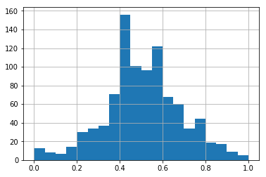

```python
df['popularity_'] = df['popularity'].map(lambda x: x/100)
df['popularity_clean'] = (df['popularity_']-df['popularity_'].min())/(df['popularity_'].max()-df['popularity_'].min())
df.drop(['popularity_'], axis=1, inplace=True)
df['popularity_clean'].hist(bins=20)
```

### Feature 'acousticness'

According to the documentation:

> A confidence measure from 0.0 to 1.0 of whether the track is acoustic. 1.0 represents high confidence the track is acoustic.

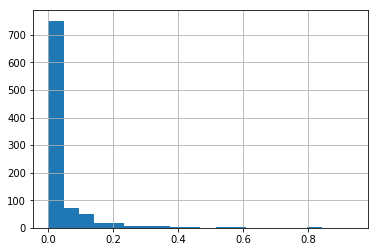

```python
df['acousticness'].hist(bins=20)
```

The data is highly skewed. Let's use log transformation to normalize.

```python
df['acousticness_'] = df['acousticness'].map(lambda x: np.log(x))
df['acousticness_clean'] = (df['acousticness_']-df['acousticness_'].min())/(df['acousticness_'].max()-df['acousticness_'].min())
df.drop(['acousticness_'], axis=1, inplace=True)
```

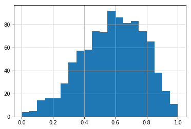

```python
df['acousticness_clean'].hist(bins=20)
```

### Feature 'danceability'

According to the documentation:

> Danceability describes how suitable a track is for dancing based on a combination of musical elements including tempo, rhythm stability, beat strength, and overall regularity. A value of 0.0 is least danceable and 1.0 is most danceable.

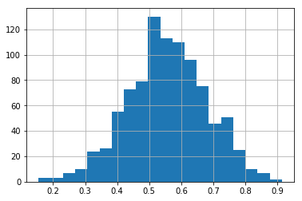

```python
df['danceability'].hist(bins=20)
```

This feature looks good. No need to work on this one. We will just normalize it.

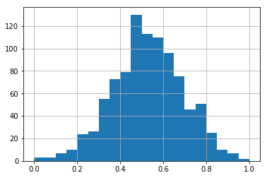

```python
df['danceability_clean'] = (df['danceability']-df['danceability'].min())/(df['danceability'].max()-df['danceability'].min())
df['danceability_clean'].hist(bins=20)
```

### Feature 'duration_ms'

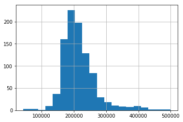

```python
df['duration_ms'].hist(bins=20)
```

The data is a little skewed. Since this feature represents the track duration, we will allow it to pull the fit line (or in our case principal component) closer, since we are fine with tracks around the 200000ms mark.

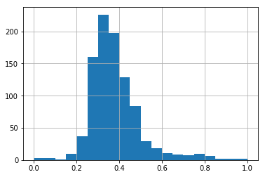

```python
df['duration_ms_clean'] = (df['duration_ms']-df['duration_ms'].min())/(df['duration_ms'].max()-df['duration_ms'].min())
df['duration_ms_clean'].hist(bins=20)
```

### Feature 'energy'

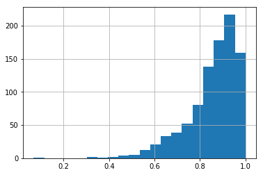

```python
df['energy'].hist(bins=20)
```

A lot of the tracks seem to be energetic. I think I am fine with leaving this feature skewed.

> Energy is a measure from 0.0 to 1.0 and represents a perceptual measure of intensity and activity. Typically, energetic tracks feel fast, loud, and noisy. For example, death metal has high energy, while a Bach prelude scores low on the scale. Perceptual features contributing to this attribute include dynamic range, perceived loudness, timbre, onset rate, and general entropy.

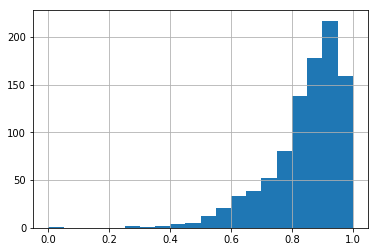

```python
df['energy_clean'] = (df['energy']-df['energy'].min())/(df['energy'].max()-df['energy'].min())
df['energy_clean'].hist(bins=20)
```

### Feature 'instrumentalness'

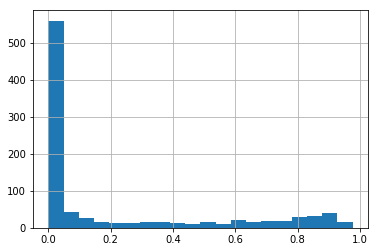

```python
df['instrumentalness'].hist(bins=20)
```

So this data appears to be skewed as well.

> Predicts whether a track contains no vocals. “Ooh” and “aah” sounds are treated as instrumental in this context. Rap or spoken word tracks are clearly “vocal”. The closer the instrumentalness value is to 1.0, the greater likelihood the track contains no vocal content. Values above 0.5 are intended to represent instrumental tracks, but confidence is higher as the value approaches 1.0.

Knowing this, I would propose to scale everything above 0.5 to 0.5 and then rescale from 0 to 1. This will promote non-vocal and vocal tracks "equally".

```python
df['instrumentalness_'] = df['instrumentalness'].map(lambda x: 0.5 if x > 0.5 else x)
df['instrumentalness_clean'] = (df['instrumentalness_']-df['instrumentalness_'].min())/(df['instrumentalness_'].max()-df['instrumentalness_'].min())
df.drop(['instrumentalness_'], axis=1, inplace=True)
```

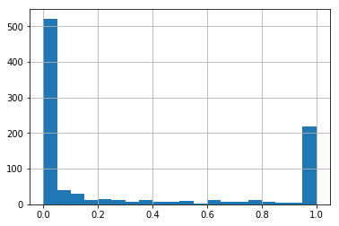

```python
df['instrumentalness_clean'].hist(bins=20)
```

### Feature 'key'

> The estimated overall key of the track. Integers map to pitches using standard Pitch Class notation . E.g. 0 = C, 1 = C♯/D♭, 2 = D, and so on. If no key was detected, the value is -1.

Therefore, we can map it to a more human readable format.

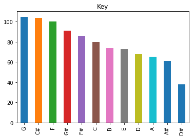

```python
tonal = ['C','C#','D','D#','E','F','F#','G','G#','A','A#','B']
df['key'].map(lambda i: tonal[int(i)]).value_counts().plot.bar(title='Key')
```

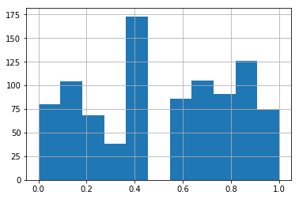

```python
df['key_clean'] = (df['key']-df['key'].min())/(df['key'].max()-df['key'].min())
df['key_clean'].hist(bins=11)
```

### Feature 'liveness'

> Detects the presence of an audience in the recording. Higher liveness values represent an increased probability that the track was performed live. A value above 0.8 provides strong likelihood that the track is live.

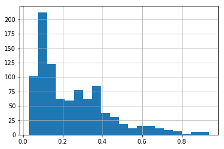

```python
df['liveness'].hist(bins=20)
```

It looks like 'live' tracks are not really present in the playlist. Neither should they. Hence, we will not fiddle with this representation and let it be as is.

```python
df['liveness_clean'] = (df['liveness']-df['liveness'].min())/(df['liveness'].max()-df['liveness'].min())
```

### Feature 'loudness'

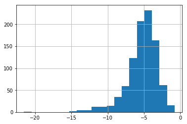

```python
df['loudness'].hist(bins=20)
```

> The overall loudness of a track in decibels (dB). Loudness values are averaged across the entire track and are useful for comparing relative loudness of tracks. Loudness is the quality of a sound that is the primary psychological correlate of physical strength (amplitude). Values typical range between -60 and 0 db.

This is another value that should be left as is. We will normalize it though.

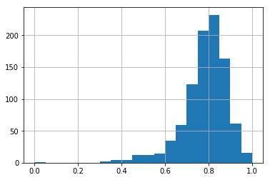

```python
df['loudness_clean'] = (df['loudness']-df['loudness'].min())/(df['loudness'].max()-df['loudness'].min())
df['loudness_clean'].hist(bins=20)
```

### Feature 'mode'

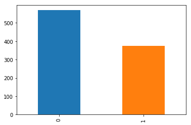

```python
df['mode'].value_counts().plot.bar()
```

> Mode indicates the modality (major or minor) of a track, the type of scale from which its melodic content is derived. Major is represented by 1 and minor is 0.

```python
df.drop(['mode'], axis=1, inplace=True)
```

### Feature 'speechiness'

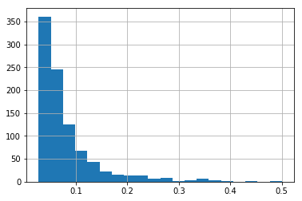

```python
df['speechiness'].hist(bins=20)
```

> Speechiness detects the presence of spoken words in a track. The more exclusively speech-like the recording (e.g. talk show, audio book, poetry), the closer to 1.0 the attribute value. Values above 0.66 describe tracks that are probably made entirely of spoken words. Values between 0.33 and 0.66 describe tracks that may contain both music and speech, either in sections or layered, including such cases as rap music. Values below 0.33 most likely represent music and other non-speech-like tracks.

This feature should be treated as 'acousticness'.

```python
df['speechiness_'] = df['speechiness'].map(lambda x: np.log(x))
df['speechiness_clean'] = (df['speechiness_']-df['speechiness_'].min())/(df['speechiness_'].max()-df['speechiness_'].min())
df.drop(['speechiness_'], axis=1, inplace=True)
```

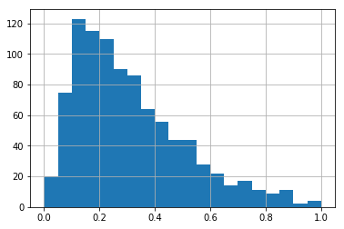

```python
df['speechiness_clean'].hist(bins=20)
```

### Feature 'tempo'

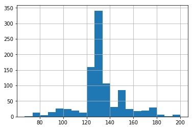

```python
df['tempo'].hist(bins=20)
```

> The overall estimated tempo of a track in beats per minute (BPM). In musical terminology, tempo is the speed or pace of a given piece and derives directly from the average beat duration.

This feature seems fine and kind of expected. Simple normalization will do.

```python
df['tempo_clean'] = (df['tempo']-df['tempo'].min())/(df['tempo'].max()-df['tempo'].min())
```

### Feature 'time_signature'

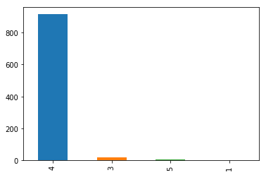

```python
df['time_signature'].value_counts().plot.bar()
```

> An estimated overall time signature of a track. The time signature (meter) is a notational convention to specify how many beats are in each bar (or measure).

Similar to 'mode', this feature is not really helpful. We will drop it too.

```python
df.drop(['time_signature'], axis=1, inplace=True)
```

### Feature 'valence'

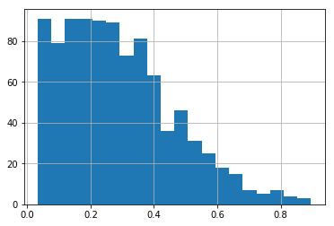

```python
df['valence'].hist(bins=20)
```

> A measure from 0.0 to 1.0 describing the musical positiveness conveyed by a track. Tracks with high valence sound more positive (e.g. happy, cheerful, euphoric), while tracks with low valence sound more negative (e.g. sad, depressed, angry).

```python
df['valence_clean'] = (df['valence']-df['valence'].min())/(df['valence'].max()-df['valence'].min())
```

## Visualization of cleaning

```python
columns_for_processing = [x for x in list(df.columns) if 'clean' in x]
columns_for_processing.append('id')
df_clean = df[columns_for_processing].copy()
df_clean.rename(columns=lambda x: x.replace('_clean', ''), inplace=True)
```

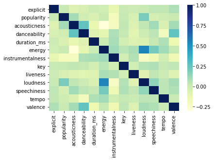

```python
sns.heatmap(df_clean.corr(),cmap="YlGnBu")
```

Let's see this on a nice spider chart.

```python
def plot_spider(df, categories, title=''):
    """Function to plot a spider/radar chart

    Args:
        df: The data frame to plot. Requires to be in th following format format:
            | feature1 | feature2 | ... | featureN |
          # | 0        | 1        | ... | -1       |
          Note: Only one row is allowed to the dataframe.
        categories: The categories, i.e. names of each feature.
        title: The title to be displayed over the plot. Default: ''

    Returns:
        Nothing (however, plots the radar chart directly)

    """
    # credits to: https://python-graph-gallery.com/390-basic-radar-chart/

    N = len(categories)

    # We are going to plot the first line of the data frame.
    # But we need to repeat the first value to close the circular graph:
    values=df.values.flatten().tolist()
    values += values[:1]
    values

    # What will be the angle of each axis in the plot? (we divide the plot / number of variable)
    angles = [n / float(N) * 2 * pi for n in range(N)]
    angles += angles[:1]

    # Initialise the spider plot
    plt.figure(figsize=(8,8))
    ax = plt.subplot(111, polar=True)

    # Draw one axe per variable + add labels labels yet
    plt.xticks(angles[:-1], categories, color='black', size=15)

    # Draw ylabels
    ax.set_rlabel_position(0)
    plt.yticks([0,0.1,0.2,0.3,0.4,0.5,0.6,0.7,0.8,0.9,1], ['0','0.1','0.2','0.3','0.4','0.5','0.6','0.7','0.8','0.9','1'], color="grey", size=10)
    plt.ylim(0,1)

    # Plot title
    plt.title(title, size=20)

    # Plot data
    ax.plot(angles, values, linewidth=1, linestyle='solid')

    # Fill area
    ax.fill(angles, values, 'b', alpha=0.1)
```

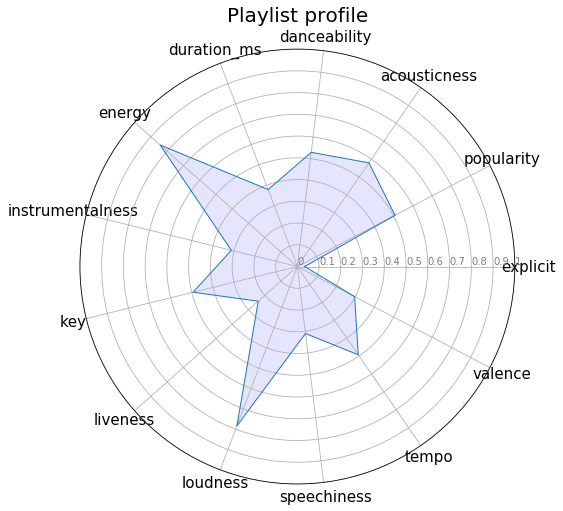

```python
plot_spider(df_clean[[x for x in df_clean.columns if 'id' not in x]].mean(), [x for x in df_clean.columns if 'id' not in x], 'Playlist profile')
```

This spider chart, gives a good idea of the playlist. Let's see if we can find clusters or principal components inside the data to group the tracks inside that playlist. We should then get more "extreme" profiles.

## Playlist analysis

Given the spider plot above, it seems that a (subset of a) playlist can be described quite well with the selected features.

The following analysis builds upon the premise, that we have various clusters of tracks inside our playlist.

For analysis we will use PCA to help us disect the individual subsets.

```python
from sklearn.decomposition import PCA
```

To understand how a principal component describes the data at hand, we will use a scree plot. For plotting we will re-use a function we used in an earlier project.

```python
def scree_plot(pca):
    '''
    Creates a scree plot associated with the principal components

    INPUT: pca - the result of instantian of PCA in scikit learn

    OUTPUT:
            None
    '''
    num_components = len(pca.explained_variance_ratio_)
    ind = np.arange(num_components)
    vals = pca.explained_variance_ratio_

    plt.figure(figsize=(10, 6))
    ax = plt.subplot(111)
    cumvals = np.cumsum(vals)
    ax.bar(ind, vals)
    ax.plot(ind, cumvals)

    ax.xaxis.set_tick_params(width=0)
    ax.yaxis.set_tick_params(width=2, length=12)

    ax.set_xlabel("Principal Component")
    ax.set_ylabel("Variance Explained (%)")
    plt.title('Explained Variance Per Principal Component')
```

```python
# Set up PCA
pca = PCA()
df_pca = pca.fit(df_clean.loc[:, ~df_clean.columns.isin(['id'])])
```

Let's get a rough understanding of the data.

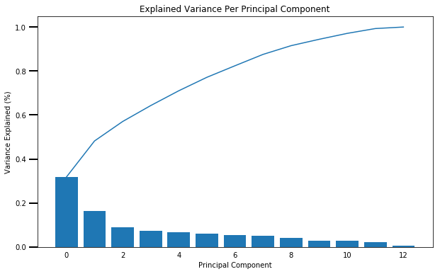

```python
scree_plot(df_pca)
```

To continue we can start interpreting the components.

```python
def pca_weights(pca, i):
    '''
    Maps the features names to the components and sorts them by their weight

    INPUT:
        pca - the result of instantian of PCA in scikit learn
        i - The number of the principal component (i.e. dimension)

    OUTPUT:
            Dataframe with sorted weights for a given principal component
    '''
    df = pd.DataFrame(pca.components_, columns=list([column for column in df_clean.columns if column != 'id']))
    weights = df.iloc[i].sort_values(ascending=False)
    return weights
```

```python
def plot_pca_weights(pca, dimension, title, figsize=(14, 6)):
    '''
    Plots the principal component

    INPUT:
        pca - the result of instantian of PCA in scikit learn
        dimension - The number of the principal component

    OUTPUT:
            Plot
    '''
    # Collect dimension info
    weights = pca_weights(pca, dimension)

    # Create bar plot
    plt.figure(figsize=figsize)
    weights.plot(kind='bar')
    plt.axhline(y=0, ls='--', c='#b3b3b3', lw=1)
    plt.ylabel("Feature Weights")
    plt.subplots_adjust(bottom=0.8)
    plt.suptitle("Variance Explained: {}".format(title), fontsize=18)
    plt.tight_layout()
```

```python
def pca_extreme_features(pca, dimension, n):
    '''
    Returns the n most extreme features

    INPUT:
        pca - the result of instantian of PCA in scikit learn
        dimension - The number of the principal component
        n - the number of features of each extremity

    OUTPUT:
        List of names of the most extreme features
    '''
    weights = pca_weights(pca, dimension)
    high_positive = weights[weights >= 0].sort_values(ascending=False)
    high_negative = weights[weights < 0].sort_values()
    print("Highly Positive Features\n", high_positive[:n])
    print("\nHighly Negative Features\n", high_negative[:n])
    return high_positive[:n], high_negative[:n]
```

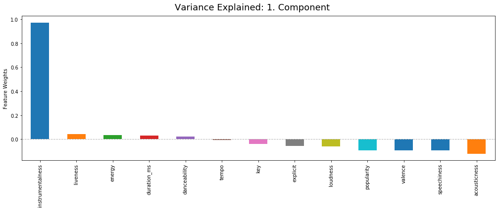

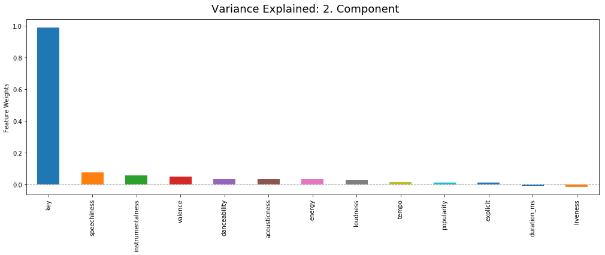

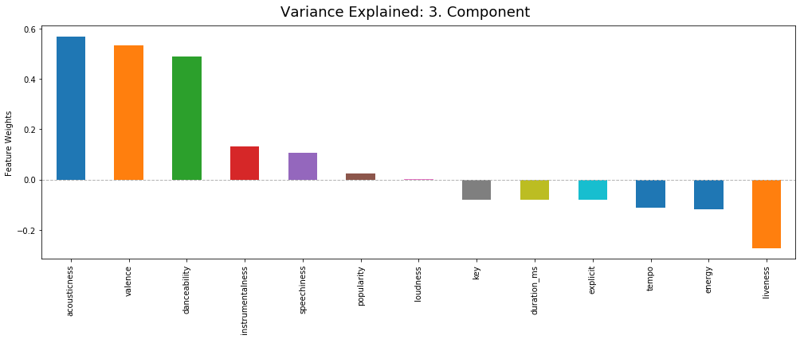

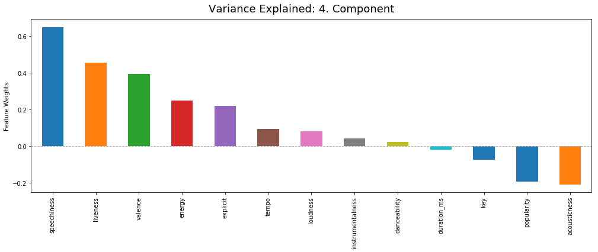

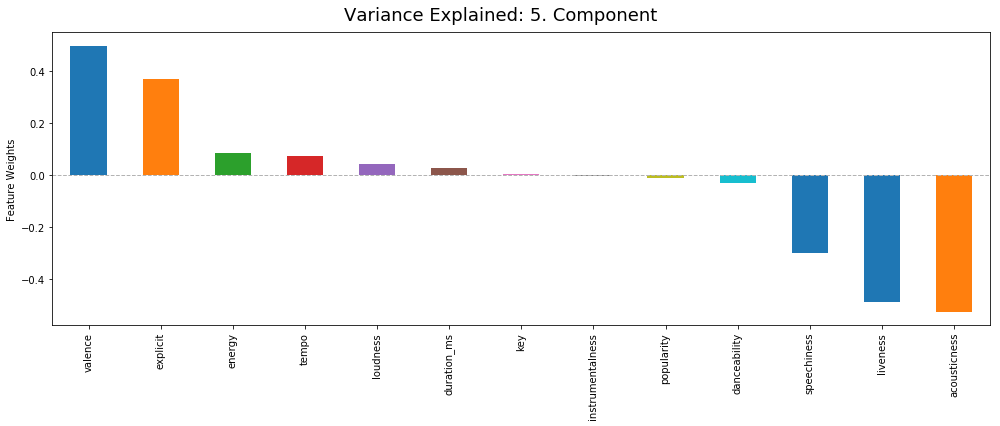

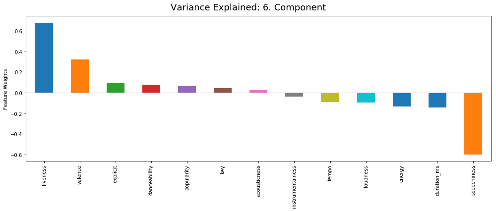

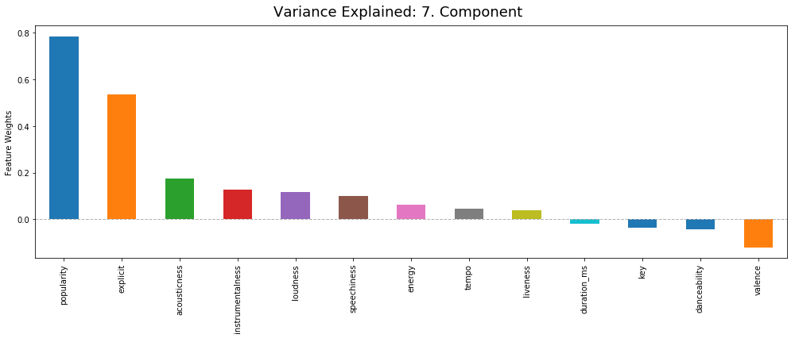

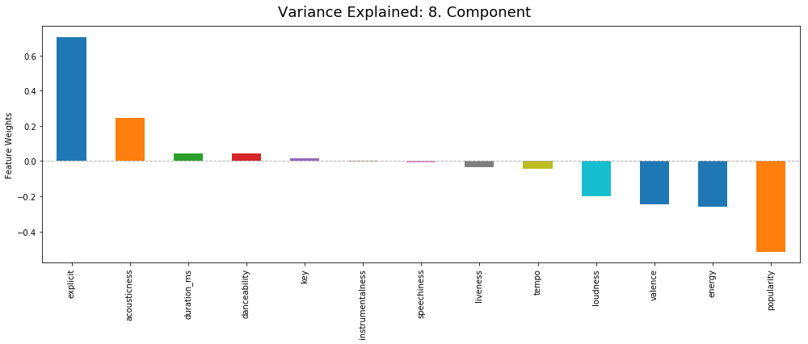

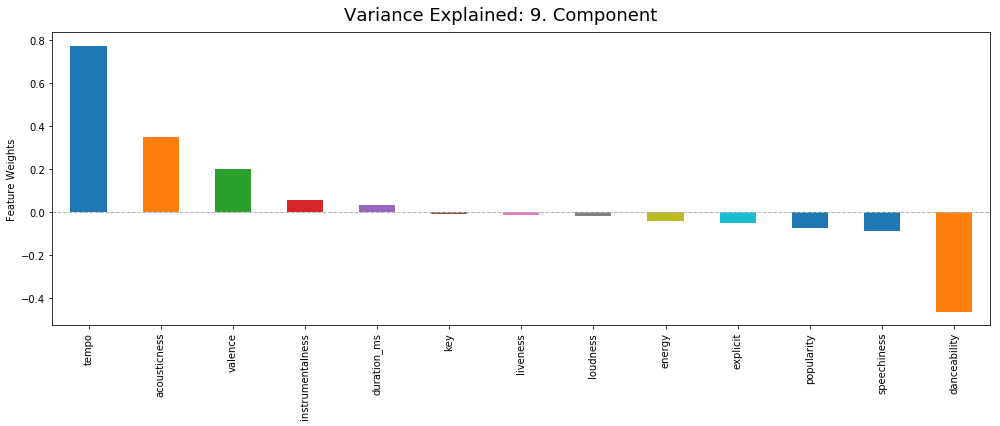

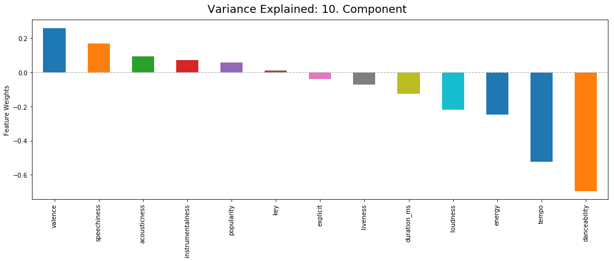

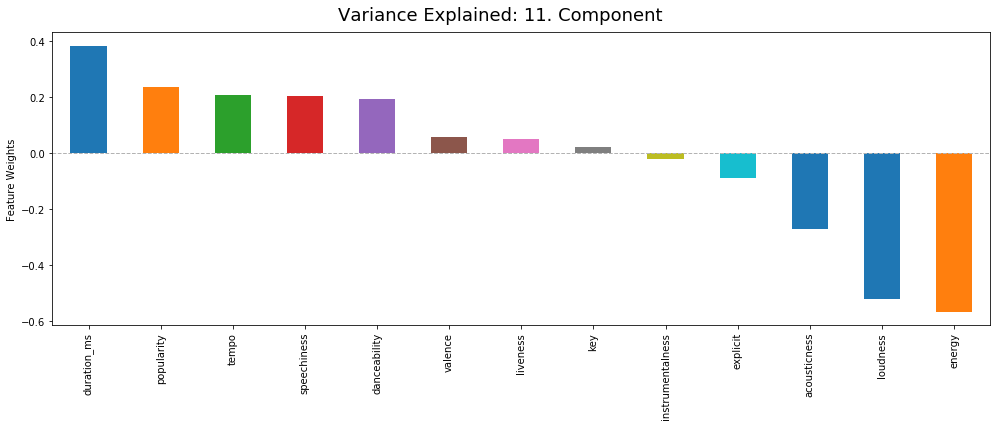

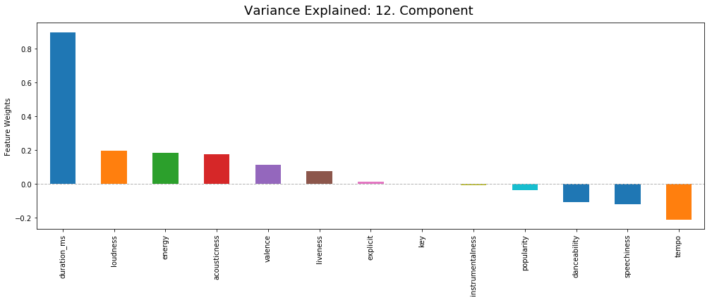

[1 more figures not shown]

```python
for i in range(len(pca.explained_variance_ratio_)):
    plot_pca_weights(pca, i, '{}. Component'.format(i+1))
```

Let's see whether we can see something in the data. We do see that there is some sort of correlation of the data, but it we want to see whether we can see the actual clusters.

```python
def scatter(x, colors):
    # choose a color palette with seaborn.
    num_classes = len(np.unique(colors))
    palette = np.array(sns.color_palette("hls", num_classes))

    # create a scatter plot.
    f = plt.figure(figsize=(8, 8))
    ax = plt.subplot(aspect='equal')
    sc = ax.scatter(x[:,0], x[:,1], lw=0, s=40, c=palette[colors.astype(np.int)])
    plt.xlim(-25, 25)
    plt.ylim(-25, 25)
    ax.axis('off')
    ax.axis('tight')

    # add the labels for each digit corresponding to the label
    txts = []

    for i in range(num_classes):

        # Position of each label at median of data points.

        xtext, ytext = np.median(x[colors == i, :], axis=0)
        txt = ax.text(xtext, ytext, str(i), fontsize=24)
        txt.set_path_effects([
            PathEffects.Stroke(linewidth=5, foreground="w"),
            PathEffects.Normal()])
        txts.append(txt)

    return f, ax, sc, txts
```

```
(<Figure size 576x576 with 1 Axes>,
 [Text(-0.26005623564354347, 0.016986724806981074, '0')])
```

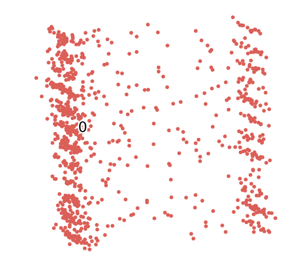

```python
pca_df = pd.DataFrame(columns = ['pca1','pca2'])
p = pca.transform(df_clean.loc[:, ~df_clean.columns.isin(['id'])])
pca_df['pca1'] = p[:,0]
pca_df['pca2'] = p[:,1]
top_two_comp = pca_df[['pca1','pca2']] # taking first and second principal component

scatter(top_two_comp.values,np.zeros(top_two_comp.shape[0]))
```

We can somewhat clearly recognize two clusters in the dataset. This makes sense, as I am listening to two kinds of music regularly (either Rock influenced or EDM influenced music).

## Playlist clustering

We can now cluster the playlist data into clusters. For this we will use kMeans.

```python
from sklearn.cluster import KMeans
from tqdm import tqdm, tqdm_notebook
```

```python
X = pca.transform(df_clean.loc[:, ~df_clean.columns.isin(['id'])])
sum_of_squared_distances = []
K = range(1,30)
for k in tqdm_notebook(K):
    # run k-means clustering on the data and...
    kmeans = KMeans(n_clusters=k,init='k-means++', random_state=1337)
    kmeans.fit(X)
    # compute the average within-cluster distances.
    sum_of_squared_distances.append(kmeans.inertia_)
```

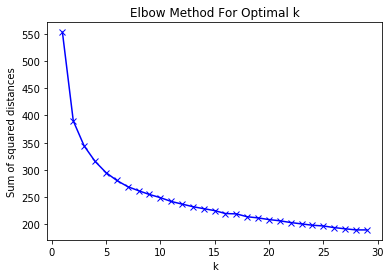

```python
# Visualising the change in within-cluster distance across number of clusters.

plt.plot(K, sum_of_squared_distances, 'bx-')
plt.xlabel('k')
plt.ylabel('Sum of squared distances')
plt.title('Elbow Method For Optimal k')
plt.show()
```

As expected from the scatter plot above, the only thing that somehow resembles an elbow for the elbow method is k=2.

```python
# Refitting kMeans

kmeans_2 = KMeans(n_clusters=2,init='k-means++', random_state=1337).fit(X)
```

```python
# Let's predict the cluster labels
prediction = pd.DataFrame(np.array(kmeans_2.predict(X)), columns=['label'])
```

Let's see how the clustering went.

[output not shown]

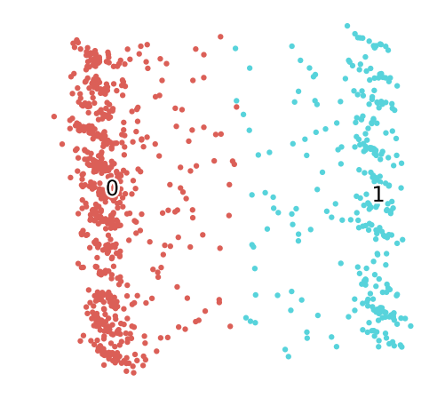

```python
pca = PCA(n_components=2)
pca_result = pca.fit_transform(df_clean.loc[:, ~df_clean.columns.isin(['id'])])
scatter(pca_result, np.array([x[0] for x in prediction.values]))
```

### Clustering improvement

We will first try to do improve clustering using DBSCAN. Since this is an unsupervised clustering algorithm, we will use the silhouette score to test the quality of the clusters.

```python
from sklearn.cluster import DBSCAN
from sklearn import metrics
from sklearn.cluster import AffinityPropagation
from sklearn.model_selection import GridSearchCV
```

```python
def cv_silhouette_scorer(estimator, X):
    estimator.fit(X)
    cluster_labels = estimator.labels_
    num_labels = len(set(cluster_labels))
    num_samples = len(X.index)
    if num_labels == 1 or num_labels == num_samples:
        return -1
    else:
        return metrics.silhouette_score(X, cluster_labels, metric='sqeuclidean')
```

```python
class DisabledCV:
    def __init__(self):
        self.n_splits = 1

    def split(self, X, y=None, groups=None):
        yield (np.arange(len(X)), np.arange(len(X)))

    def get_n_splits(self, X, y, groups=None):
        return self.n_splits
```

```python
parameters = {
        'eps': (0.5,0.75,1,1.25,1.5,2,3,4),
        'min_samples': (1,2,3,4,5,6,7,8,9,10),
        'metric': ('cosine','euclidean','manhattan')
    }
gs = GridSearchCV(estimator=DBSCAN(), param_grid=parameters,
                  scoring=cv_silhouette_scorer, cv=DisabledCV(), n_jobs=-1)
gs.fit(df_clean.loc[:, ~df_clean.columns.isin(['id'])])
```

```
GridSearchCV(cv=<__main__.DisabledCV object at 0x000001FDD0FBF7B8>,
       error_score='raise-deprecating',
       estimator=DBSCAN(algorithm='auto', eps=0.5, leaf_size=30, metric='euclidean',
    metric_params=None, min_samples=5, n_jobs=None, p=None),
       fit_params=None, iid='warn', n_jobs=-1,
       param_grid={'eps': (0.5, 0.75, 1, 1.25, 1.5, 2, 3, 4), 'min_samples': (1, 2, 3, 4, 5, 6, 7, 8, 9, 10), 'metric': ('cosine', 'euclidean', 'manhattan')},
       pre_dispatch='2*n_jobs', refit=True, return_train_score='warn',
       scoring=<function cv_silhouette_scorer at 0x000001FDD71F58C8>,
       verbose=0)
```

```python
def scatter_no_texts(x, colors):
    # choose a color palette with seaborn.
    num_classes = len(np.unique(colors))
    palette = np.array(sns.color_palette("hls", num_classes))

    # create a scatter plot.
    f = plt.figure(figsize=(8, 8))
    ax = plt.subplot(aspect='equal')
    sc = ax.scatter(x[:,0], x[:,1], lw=0, s=40, c=palette[colors.astype(np.int)])
    plt.xlim(-25, 25)
    plt.ylim(-25, 25)
    ax.axis('off')
    ax.axis('tight')

    # add the labels for each digit corresponding to the label
    txts = []

    return f, ax, sc, txts
```

```
(<Figure size 576x576 with 1 Axes>,
 [])
```

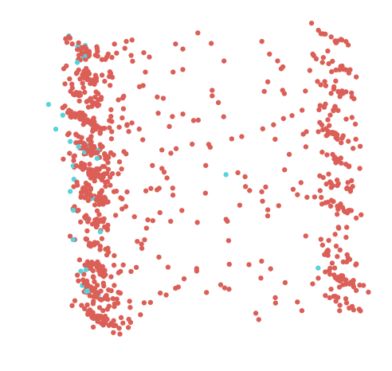

```python
clustering = DBSCAN(eps=gs.best_params_['eps'], min_samples=gs.best_params_['min_samples']).fit(X)
scatter_no_texts(pca_result, np.array([abs(x) for x in list(clustering.labels_)]))
```

This is not great. It could also be that the result just looks weird because of our way of utilizing PCA. We used the silhouette score in the cross validation to optimize the model results. So the representation above is the best possible result. Let's try again using Affinity Propagation.

```
Estimated number of clusters: 4
Silhouette Coefficient: 0.330
```

```
(<Figure size 576x576 with 1 Axes>,
 [])
```

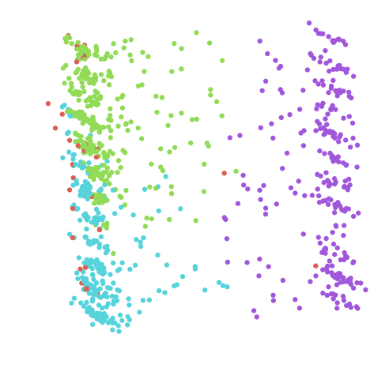

```python
af = AffinityPropagation(preference=-25).fit(X)
cluster_centers_indices = af.cluster_centers_indices_
labels = af.labels_

n_clusters_ = len(cluster_centers_indices)

print('Estimated number of clusters: %d' % n_clusters_)
print("Silhouette Coefficient: %0.3f"
      % metrics.silhouette_score(X, labels, metric='sqeuclidean'))
scatter_no_texts(pca_result, np.array([abs(x) for x in labels]))
```

In this representation above after the adhoc run of AffinityPropagation we can clearly see that AffinityPropagation is better able to cluster our tracks. Let's run cross validation to see if we can further improve the results.

```python
parameters = {
    'preference': (-50, -45, -40, -35, -30, -25, -20, -15, -10, -5)
}
gs = GridSearchCV(estimator=AffinityPropagation(), param_grid=parameters,
                  scoring=cv_silhouette_scorer, cv=DisabledCV(), n_jobs=-1)
gs.fit(df_clean.loc[:, ~df_clean.columns.isin(['id'])])
gs.best_params_
```

```
{'preference': -25}
```

It turns out, that our random guess of -25 for preference in the adhoc run was already the best possible configuration in our current setup for AffinityPropagation. Let's continue...

```python
clustered_df = pd.concat([df_clean, pd.DataFrame(labels, columns=['label'])], axis=1)
clustered_df.head()
```

|  | explicit | popularity | acousticness | danceability | duration_ms | energy | instrumentalness | key | liveness | loudness | speechiness | tempo | valence | id | label |
| --- | --- | --- | --- | --- | --- | --- | --- | --- | --- | --- | --- | --- | --- | --- | --- |
| 0 | 0.0 | 0.000000 | 0.641932 | 0.696970 | 0.439649 | 0.911989 | 0.266000 | 0.454545 | 0.111429 | 0.874934 | 0.178586 | 0.435499 | 0.146963 | 01FwoJVHy55BqEzf9hTtyf | 1.0 |
| 1 | 0.0 | 0.347826 | 0.610333 | 0.386034 | 0.474615 | 0.871203 | 0.000021 | 0.727273 | 0.072341 | 0.890030 | 0.550553 | 0.775184 | 0.418173 | 0LTq2r4sWXgrlJk5gfjanc | 1.0 |
| 2 | 0.0 | 0.391304 | 0.656771 | 0.566535 | 0.256246 | 0.928088 | 0.026400 | 0.545455 | 0.187404 | 0.848985 | 0.339528 | 0.458379 | 0.265183 | 0d04hp9JU5pkMoSFotxkmY | 1.0 |
| 3 | 0.0 | 0.463768 | 0.468766 | 0.620553 | 0.377708 | 0.845444 | 1.000000 | 0.727273 | 0.144462 | 0.800270 | 0.247317 | 0.458327 | 0.347473 | 144Jdqnukv2zebyt6vq9H8 | 3.0 |
| 4 | 0.0 | 0.318841 | 0.350146 | 0.458498 | 0.396086 | 0.966727 | 1.000000 | 0.818182 | 0.365778 | 0.761684 | 0.132383 | 0.548672 | 0.295318 | 1LWM8ybNxkIWf8QqEafcP1 | 3.0 |

Let's have a closer look what we have got.

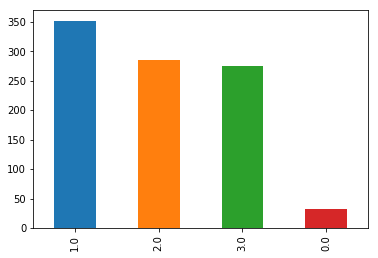

```python
clustered_df['label'].value_counts().plot(kind='bar')
```

The first cluster has the following characteristcs:

```python
def plot_features(data, title, figsize=(14, 5)):
    '''
    Plots the features

    INPUT:
        pca - the result of instantian of PCA in scikit learn
        dimension - The number of the principal component

    OUTPUT:
            Plot
    '''
    data = data.sort_values(ascending=False)

    # Create bar plot
    plt.figure(figsize=figsize)
    data.plot(kind='bar')
    plt.axhline(y=0, ls='--', c='#b3b3b3', lw=1)
    plt.ylabel("Value")
    plt.subplots_adjust(bottom=0.5)
    plt.suptitle("{}".format(title), fontsize=15)
    plt.tight_layout()
```

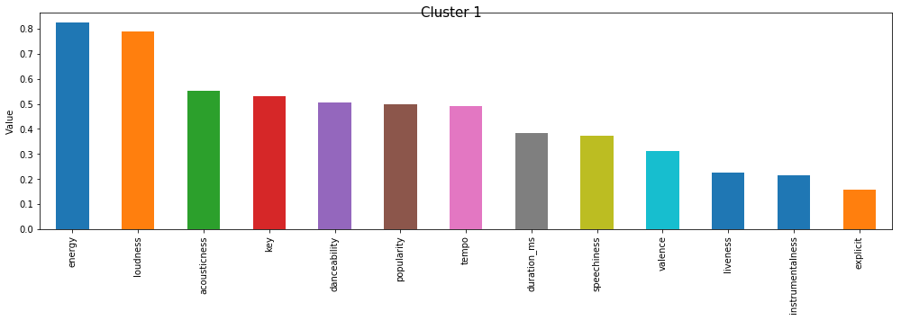

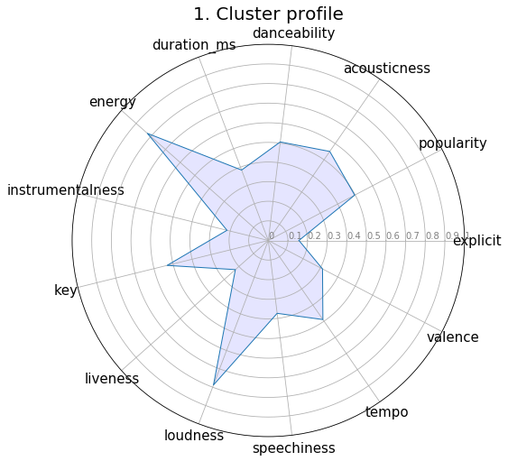

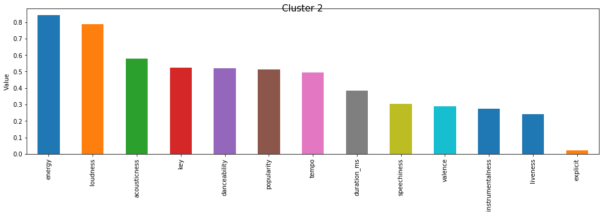

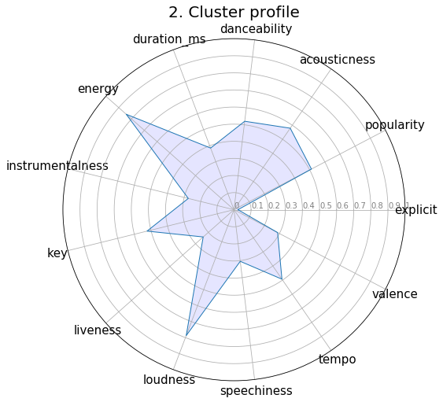

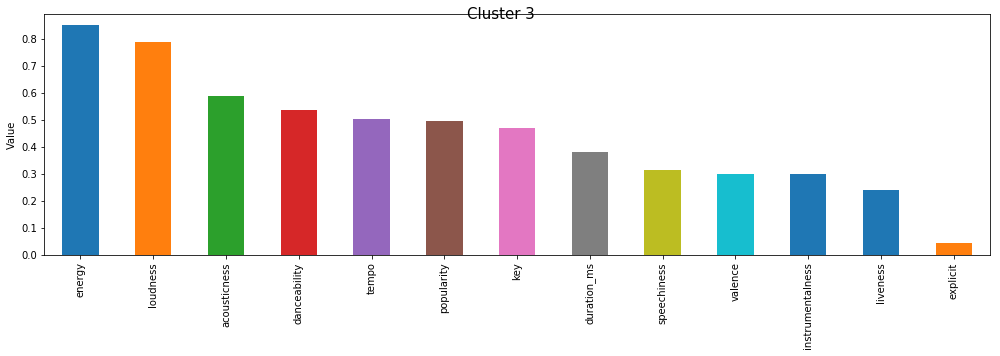

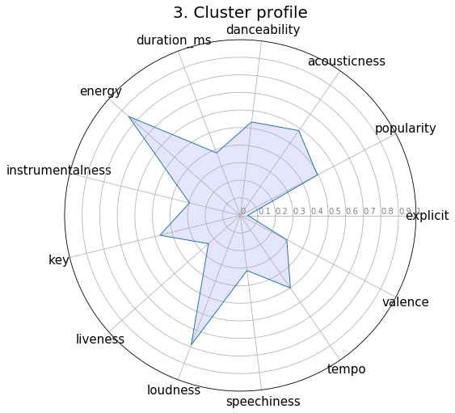

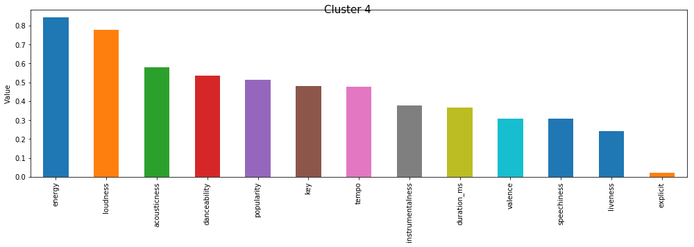

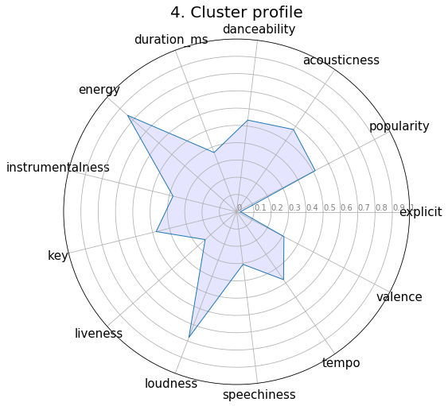

```python
for i in range(clustered_df['label'].nunique()):
    cluster = clustered_df.loc[clustered_df['label']== i]
    cluster_data = cluster.loc[:, ~cluster.columns.isin(['id','label'])]
    plot_features(cluster_data.mean(), 'Cluster {}'.format(i+1))
    plot_spider(cluster_data[cluster_data.columns].mean(), cluster_data.columns, '{}. Cluster profile'.format(i+1))
```

From our profile we cannot really tell the difference. This is okey. As the profile resembles my musical taste. It is worth noting that the source of the data at hand in this example, is an accumulated list of tracks recommended by Spotify. Hence, all of the tracks are highly similar, elsewhise Spotify would not recommend them to me. So my spider plot will most likely not change. If we would have received significantly varying spider plots, that would mean we would have beaten Spotify's recommendation engine.

## Verification

So what kind of tracks are in the clusters?

```python
trackmeta = pd.read_pickle(trackinfo)
```

```python
cluster_results = pd.merge(trackmeta, clustered_df[['id','label']], on='id', suffixes=('_trackmeta','_cluster'), how='inner')
```

```python
cluster_results.loc[cluster_results['label']==0].head(10)['name']
```

```
21                                           JESSE JAMES
34                                           Tender Lies
57                                                  2BAE
98                                Get Money - Radio Edit
175                                             Kamikaze
201                      The Feels - Nath Jennings Remix
203    Electronic Universe (Easter Rave Hymn 2k18) - ...
225                                Melody - ANGEMI Remix
299                       Because You're Here - 2018 Mix
308                                      Make 'Em Bounce
Name: name, dtype: object
```

```python
cluster_results.loc[cluster_results['label']==1].head(10)['name']
```

```
0     Darker Than The Light That Never Bleeds - Ches...
1                             By Your Side (feat. Emel)
2                                         Alone Tonight
10                                               Meraki
12                                              Runaway
15                         Project 1 - Sound Rush Remix
16                                        Guilty as Sin
20                                                 Home
22                     Sparks Fly - Jackson Snapp Remix
23                          Believer - Frontliner Remix
Name: name, dtype: object
```

```python
cluster_results.loc[cluster_results['label']==2].head(10)['name']
```

```
5                                       Hold On Me
6                    Heart of Courage - Radio Edit
7             TOXICITY - DeepDelic & Lowderz Remix
8                                Owe You Something
11         Long Way Home - Ashley Wallbridge Remix
17                                       Surrender
19                       Goldengate - Extended Mix
24                       Hold It Together (EFL110)
26    Under Electric Skies (Uprize & Serion Remix)
30              Blah Blah Blah - Bassjackers Remix
Name: name, dtype: object
```

```python
cluster_results.loc[cluster_results['label']==3].head(10)['name']
```

```
3                               Crash The Party
4                                  Black Coffee
9             Moon & The Stars - Rebourne Remix
13                          Mantra - Radio Edit
14            Fly Away (Mix Cut) - KhoMha Remix
18                              Baíle de Favela
25    Total Ownage - Eddie Bitar Extended Remix
27                                      Harpoon
28                Squadron - Arisen Flame Remix
33        The Island, Pt. 1 (Dawn) - AN21 Remix
Name: name, dtype: object
```

By looking at the track, we cannot clearly recognize awesome clustering. It definitely is not clustered by genre. However, as musical taste and a good playlist is subjective we will assume the result to be good, as the tracks are mainly based on the quality of the track. Remember, we used features such as 'energy', 'accousticness' and so on.

## Persist

```python
# handling nan cases
clustered_df[['id','label']]['label'].fillna(1337, inplace=True)
```

```python
mapping = {}
for label in clustered_df['label'].unique():
    if label == label: #check for nan, nan's are not equal to itself
        mapping[int(label)] = 'Archive Playlist {}'.format(int(label+1))
    else:
        mapping[1337] = 'Archive Playlist 1337'
print(mapping)
```

```
{1: 'Archive Playlist 2', 3: 'Archive Playlist 4', 2: 'Archive Playlist 3', 0: 'Archive Playlist 1', 1337: 'Archive Playlist 1337'}
```

```python
cluster_exportable = ((
    cluster_results[['id','label']]
).assign(label=lambda _df: _df['label'].replace(np.nan, 1337))
).assign(label=lambda _df: _df['label'].map(mapping))
```

```python
cluster_exportable.to_pickle('{}/clusters_{}.pkl'.format(data_folder,datetime.now().strftime('%Y%m%d%H%M')))
```